# Lakers and Crime

Riley Conner

2025-09-02

## Introduction

The Los Angeles Lakers hold a unique place in the city’s cultural identity, with every game drawing significant attention and emotional investment from LA residents. While sports can lead to regional pride and collective celebration, research indicates a parallel rise in domestic violence after unexpected losses (Cardazzi et. al., 2022). Our desire to understand the relationship between the Lakers and domestic violence led us to our primary second question: How does playing a Lakers game—and the game’s outcome—affect the daily volume of domestic‐violence calls in Los Angeles?

The relationship between sports outcome and crime may seem superficial at first glance, but research suggests otherwise, particularly when it comes to higher stake games. A notable study by economists David Card and Gordon B. Dahl investigated the link between family violence and emotional cues associated with wins and losses by professional football teams. They found that unexpected losses by professional football teams led to a 10% increase in the rate of at-home violence by men against their wives and girlfriends. This study shows that emotional investment in sports can have serious, real-world consequences. We wanted to look into whether this emotional tension could correlate with spikes in domestic violence reports. We are especially interested whether specific emotional catalysts – including consecutive victory or defeat sequences – serve as statistically significant predictors of domestic violence escalation. These variables potentially function as proxies for elevated aggression and frustration within affected populations. Identification of such patterns could provide law enforcement agencies with an evidence-based predictive framework to anticipate and implement targeted interventions during emotionally charged sporting events, thereby enhancing preventative measures during periods of potentially elevated risk, such as sports upsets.

## Data

Our data is a combination of two distinct datasets: (1) crime incident records collected and maintained by the Los Angeles Police Department and (2) Los Angeles Lakers game outcomes. The first dataset, which was made publicly available through the City of Los Angeles Open Data Portal, contains 1,004,876 criminal incidents reported within the city limits from 2020 to the present, updated biweekly. Each observation represents a unique crime formally documented by law enforcement, with 28 variables ranging from time and location to criminal and victim demographics. The second dataset was sourced from Basketball-Reference’s NBA game logs, which aggregate and verify league records. This includes all 82 regular season games from the 2021-2022 season with each observation being a game. There are 17 variables in the dataset ranging from when and where the game was played to the result, score, and opponent.

After joining the datasets, we selected relevant predictors. From the crime dataset, we kept Date, Month, and Weekday, and we created a binary variable called IsWeekend that will be 0 on a weekday and 1 on a weekend. From, the Lakers dataset, one of our most important variables was called Period2. Period2 was created to classify each date into one of four categories based on the Lakers’ schedule and outcomes. Dates during the NBA regular season without a game were labeled “Season-NoGame” while dates during the offseason were labeled “Off-Season.” Game days were categorized as either “Played-Win” or “Played-Loss” depending on the outcome. Variables Streak Type and Streak Length track the Lakers’ momentum with Streak Type identifying whether the team was on a winning or losing streak and Streak Length specifying how many games the streak lasted. These variables are combined into a numeric variable called Streak Num, which has positive integers for winning streaks and negative integers for losing streaks. Game and Win are binary predictor variables, with Game having ones for a game played on that date and zeros otherwise while Win has ones for a won game and zeros otherwise. The final variable, DV Count, represents the total number of domestic violence cases reported on each date. We created this variable by filtering for nine domestic violence crime codes in the CC1 variable of the crime dataset. We selected these nine codes based on the Los Angeles Open Data Portal’s UCR Reporting Guidelines (Federal Bureau of Investigation (2018).

The following table is an overview of the most important data in the joined dataset:

| date | month | weekday | is_weekend | Period2 | streak_len | streak_type | streak_num | game | win | dv_count |
| --- | --- | --- | --- | --- | --- | --- | --- | --- | --- | --- |
| 2021-10-19 | Oct | Tue | 0 | Played-Loss | 1 | loss | -1 | 1 | 0 | 64 |
| 2021-10-20 | Oct | Wed | 0 | Season-NoGame | 0 | none | 0 | 0 | 0 | 55 |
| 2021-10-21 | Oct | Thu | 0 | Season-NoGame | 0 | none | 0 | 0 | 0 | 61 |
| 2021-10-22 | Oct | Fri | 0 | Played-Loss | 2 | loss | -2 | 1 | 0 | 74 |
| 2021-10-23 | Oct | Sat | 1 | Season-NoGame | 0 | none | 0 | 0 | 0 | 68 |
| 2021-10-24 | Oct | Sun | 1 | Played-Win | 1 | win | 1 | 1 | 1 | 77 |
| 2021-10-25 | Oct | Mon | 0 | Season-NoGame | 0 | none | 0 | 0 | 0 | 59 |
| 2021-10-26 | Oct | Tue | 0 | Played-Win | 2 | win | 2 | 1 | 1 | 59 |
| 2021-10-27 | Oct | Wed | 0 | Played-Loss | 1 | loss | -1 | 1 | 0 | 66 |
| 2021-10-28 | Oct | Thu | 0 | Season-NoGame | 0 | none | 0 | 0 | 0 | 67 |

The boxplot presented below illustrates the distribution of daily domestic violence cases across different periods related to the Los Angeles Lakers’ schedule, which are displayed on the x-axis. The y-axis indicates the number of reported domestic violence incidents for each day in the dataset. The overlaid scatter plot represents the individual data points, which allows us to see the actual raw data and its distribution for each category. Notably, the “Off-Season” has the highest median number of domestic violence cases, but also the most data. Additionally, the median number of domestic violence cases during the regular season when the Lakers do not have a game is lower than on days when they do have a game, regardless of whether they win or lose. Building on these initial observations, we will further investigate the relationship between domestic violence and the outcomes of Lakers’ games.

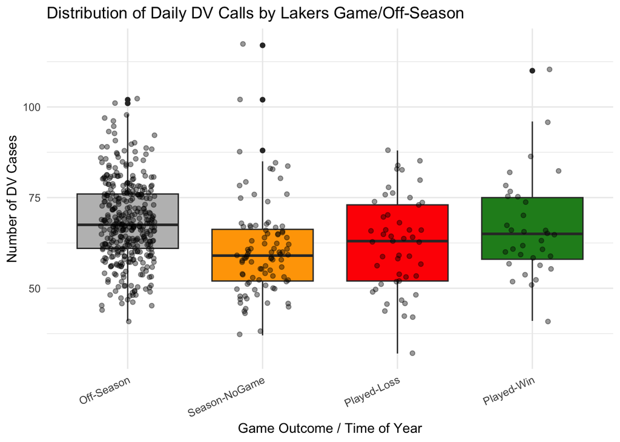

## Results

To determine the extent to which the Lakers data can predict the number of domestic violence cases reported, we constructed a series of ten models (one of them being an empty model). Given that our predictor variables were entirely categorical or binary, we decided to use modeling techniques that go beyond a simple linear regression. Some of these models focus solely on predictors derived from the Lakers game results, such as the Win or Streak Num variables, while others combine those with more general predictors, like Weekday and Month. With the exception of the Negative Binomial Model (NegBin), GAM, and the Random Forest Model (RF), which utilize a Poisson regression—a statistical method useful for modeling the number of times an event, like a domestic violence report, occurs over a fixed period. We utilize the ln() function for the link because it guarantees positive predictions and ensures that the variance doesn’t increase without bounds as the mean number of domestic violence cases grows. The following equations describe each predictor variable used in that specific model. It is important to note that although we are looking at the correlation between (1) the Lakers playing a game and (2) the game’s outcome, we added other predictor variables to our models – like Month or Is Weekend – to account for temporal predictors. In our EDA, we discovered a strong association between weekends and higher DV counts, so we added Is Weekend into several models. We also added Month to account for potential confounding seasonal patterns that could influence domestic violence patterns. It is safe for us to use both Is Weekend and Month in the same model because there is an extremely low correlation between the two, so we had no worries about multicollinearity impacting our results. Lastly, we calculated the root mean squared error (RMSE) instead of the mean squared error (MSE) for the predictions because the RMSE results are in the units of the data, making it easier to interpret the average prediction error in terms of the actual domestic violence counts.

The models we constructed were:

- Empty: DV Count = β0 + ε, ε ~ Poisson(λ), link = ln(λ)
- Result: DV Count = β0 + β1 * Win + ε, ε ~ Poisson(λ), link = ln(λ)
- Streak: DV Count = β0 + β1 * Streak Num + ε, ε ~ Poisson(λ), link = ln(λ)
- Weekend: DV Count = β0 + β1 * Is Weekend + ε, ε ~ Poisson(λ), link = ln(λ)
- Season: DV Count = β0 + β1 * Month + ε, ε ~ Poisson(λ), link = ln(λ)
- Possion: DV Count = β0 + β1 * Period2 + ε, ε ~ Poisson(λ), link = ln(λ)
- NegBin: DV Count = β0 + β1 * Period2 + ε, ε ~ NegativeBinomial(r, p)
- GAM: DV Count = β0 + β1 * Period2 + f(as.numeric(date)) + ε
- Full: DV Count = β0 + β1 * Win+ β2 * Streak Num + β3 * (Win* Streak Num) + β4 * Is Weekend + β5 * Month + ε, ε ~ Poisson(λ), link = ln(λ)
- RF: DV Count = (1/N) * Σ [Ti(Period2, Streak Len, Streak Type, Weekday, Month, Game, Win)]

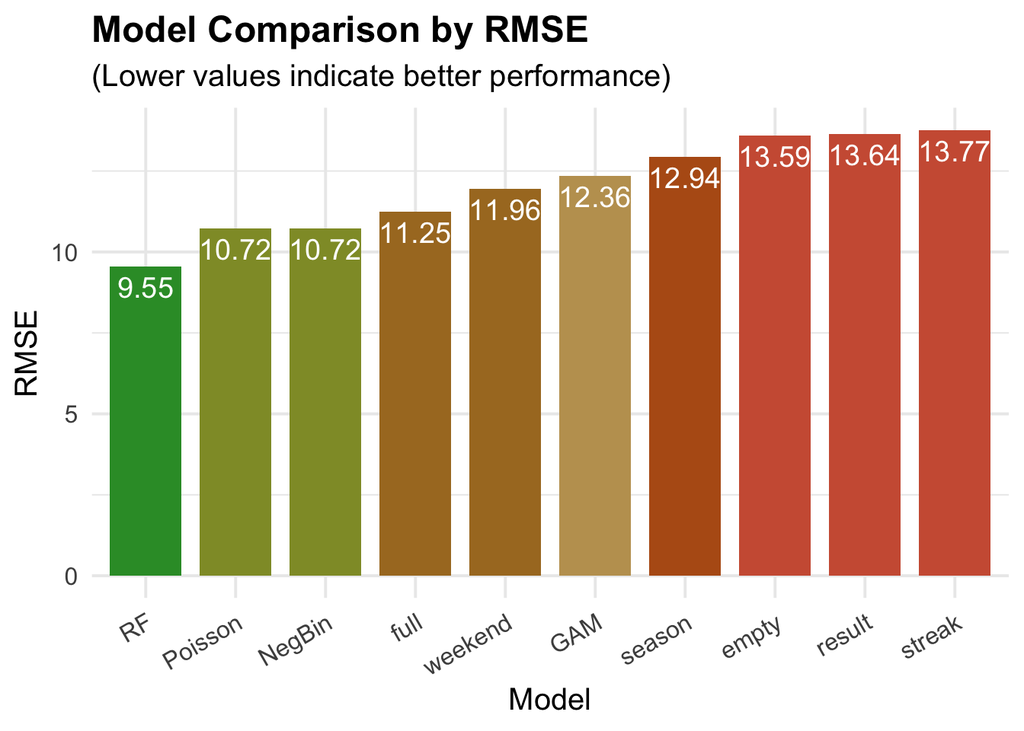

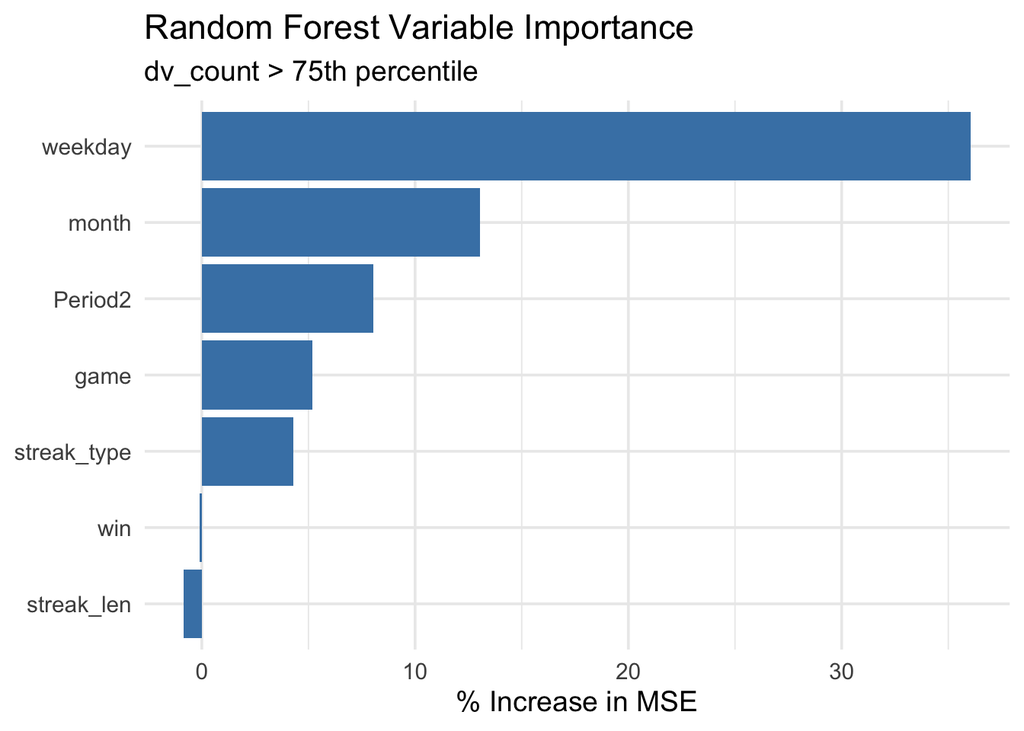

The RF model demonstrated a clear trade-off between identifying High-DV days and Low-DV days, which is illustrated in the accuracy table below. The sensitivity of 0.53 means that the model correctly classified only 53% of actual High-DV days, while the specificity of 0.93 means the model correctly classified 93% of actual Low-DV days. This suggests that our RF model is more conservative and practices a moderate amount of sensitivity. It rarely determines a High-DV day by mistake, but in doing so it misses a fair number of real high-DV days. Taken together, our results show no evidence that Lakers games—whether they win or lose—influence the amount of DV cases that occur on that day.

| Metric | Value |
| --- | --- |
| Sensitivity | 0.53 |
| Specificity | 0.93 |

## Conclusion

Surprisingly, Lakers game existence and outcome showed no significant association with domestic violence counts, while weekday and month variables emerged as our strongest predictors in our random forest model. These results have several real-world implications for law enforcement in Los Angeles. The absence of a correlation between Lakers games and domestic violence reports challenges assumptions about sports-related violence that our group originally had. Nevertheless, the strong association between weekends and domestic violence highlights the need for law enforcement to allocate resources based on weekly patterns, such as deploying additional officers on weekends.

Future studies for this question should look into alcohol consumption as a potential confounding variable as alcohol is often consumed during sports events and a contributor to domestic violence. Incorporating liquor sales or emergency room reports of alcohol related incidents could significantly improve the models, and the interaction effect between alcohol consumption and Lakers game data could be more significant than just Lakers game data alone. Additionally, more research could be done with the current data we have now. Interaction effects between calendar variables and Lakers result variables could be explored more. For example, models exploring the interaction of streak length and month could be useful especially given that months closer to the end of the regular season have more important games for playoff contention, so a streak in these months may amplify emotions for fans. Future research could also expand the scope of our findings by investigating the relationship between other sports events and overall crime rates. While this study did not find a strong link between Lakers game outcomes and domestic violence specifically, there remains the possibility that outcomes of other sporting events influence other types of crime.

## Sources

- Card, D., & Dahl, G. B. (2011). Family violence and football: The effect of unexpected emotional cues on violent behavior (No. w15497). National Bureau of Economic Research. https://davidcard.berkeley.edu/papers/card-dahl-family-violence.pdf
- Castleman, T. (2023, October 6). A troubling California trend: More violent crimes with guns even as restrictions tighten. Los Angeles Times. https://www.latimes.com/california/story/2023-10-06/a-troubling-trend-in-california-more-violent-crimes-are-being-committed-with-guns-even-as-restrictions-tighten
- Federal Bureau of Investigation. (2018, June 26). Uniform Crime Reporting (UCR) Program. U.S. Department of Justice. https://www.fbi.gov/services/cjis/ucr
- Cardazzi, A., McCannon, B. C., Humphreys, B. R., & Rodriguez, Z. (2022, July 29). Emotional cues and violent behavior: Unexpected basketball losses increase incidents of family violence. Journal of Law, Economics, and Organization, 40(2), 267–288. https://doi.org/10.1093/jleo/ewad017